# Project 1 Supplementary material

Team 15

11/11/2021

**Note: All figure/table captions were added in Word. Only x/y title and some additional notes were created via codes.**

# 1 Load Data

```r
load(here("data", "dic_full.Rdata"))
load(here("data", "tech_biom_john.Rdata"))
load(here("data", "tech_food_john.Rdata"))
load(here("data", "tech_nutr_john.Rdata"))
load(here("data", "foodcode_class.Rdata"))
```

# 2 Aims of analysis

Around our research question, we built another three aims: - Aim 1: Whether low SES groups consume more UPF compared to other SES groups - Aim 2: Whether increased UPF ratio leads to lower protein and increased energy intake ratio among the low-SES group - Aim 3: Whether UPF consumption is a significant contributor to obesity in low-SES groups

Answers from these three questions will make our final conclusion more persuasive.

Models in this analysis were mainly constructed for Aim 3. Firstly, the use of these models is to identify whether UPF consumption is significant in determining obesity. More importantly, the variable importance from the generated models (Classification trees, random forest, logistic regression and neutral networks) would be our criteria for confounding variables. We extracted important variables from each model and classified our data based on these confounding variables via K-means clustering to ensure that within each cluster, as UPF consumption increases, the effect of confounding variables on obesity could be removed.

# 3 Brief discussion of data

We would use the three datasets provided by Professor John Ormerod as our technical data to conduct further analysis.

The biomedical dataset provides most of variables we would use in answering our research question. Our models were mainly built on biomedical dataset and another newly introduced variable, UPF consumption, which was mainly derived from food dataset that records every food volunteers ate during the experiment period. Basically, items in the food dataset were classified into 5 levels by NUTM students, i.e., unprocessed, minimally processed, processed culinary, processed and ultra-processed. We then calculated the proportion of each food class consumed by each person and extracted the proportion of consumed ultra-processed foods as the indicator of UPF consumption .

Also, since our research question is built around the topic of OBESITY, we then defined our version of obesity using variables from the biomedical dataset, the ratio of waist circumference to height according, which was highly recommended by the literature found by NUTM students.

Definitely there are some inconsistencies embedded within technical datasets above but we would use them at this stage as a starting point and make necessary adjustments later. For instance, when we tried to include a variable describing the time spent on physical activity during last week into logistic regression, we found it was a factor in the dataset though it should be numerical variables. Adjustments were then applied.

# 4 Define Obesity

```r
biom_whtr = tech_biom %>% mutate(
  whtr = PHDCMWBC/PHDCMHBC
)
biom_obese = biom_whtr %>% mutate(OBESITY = case_when(
  whtr>=0.53 & SEX=="1" ~ "OBESE",
  whtr<0.53 & SEX=="1" ~ "NON-OBESE",
  whtr>=0.49 & SEX=="2" ~ "OBESE",
  whtr<0.49 & SEX=="2" ~ "NON-OBESE"
))
```

# 5 Proportion of different foods class

```r
before_ratio_data = tibble(tech_food$ABSPID, tech_food$FOODCODC, foodcode_class$Class) %>% drop_na() %>% setNames(c("id", "food_code", "class"))
before_ratio_data = before_ratio_data %>% group_by(id, class) %>%
  summarise(
    count = n()
  ) %>%
  ungroup()
foodcode_class_ratio = before_ratio_data %>% group_by(id) %>%
  summarise(
    class = class,
    ratio = count/sum(count)
  )
head(foodcode_class_ratio,10) %>% kbl(caption = "First 10 rows of foodcode_class_ratio") %>%
  kable_classic(full_width = F)
```

Table 5.1: First 10 rows of foodcode_class_ratio

| id | class | ratio |
| --- | --- | --- |
| NPA11B10000011 | Minimally processed | 0.3333333 |
| NPA11B10000011 | Processed culinary | 0.1666667 |
| NPA11B10000011 | Processed foods | 0.1296296 |
| NPA11B10000011 | Ultra-processed | 0.2962963 |
| NPA11B10000011 | Unprocessed | 0.0740741 |
| NPA11B10000021 | Minimally processed | 0.0370370 |
| NPA11B10000021 | Processed culinary | 0.1481481 |
| NPA11B10000021 | Processed foods | 0.3333333 |
| NPA11B10000021 | Ultra-processed | 0.1481481 |
| NPA11B10000021 | Unprocessed | 0.3333333 |

The food dataset was grouped by ID and five foods levels. Then the proportion of each level for each person was available.

# 6 Aim 1: Whether low-SES groups consume more UPF compared to other SES groups

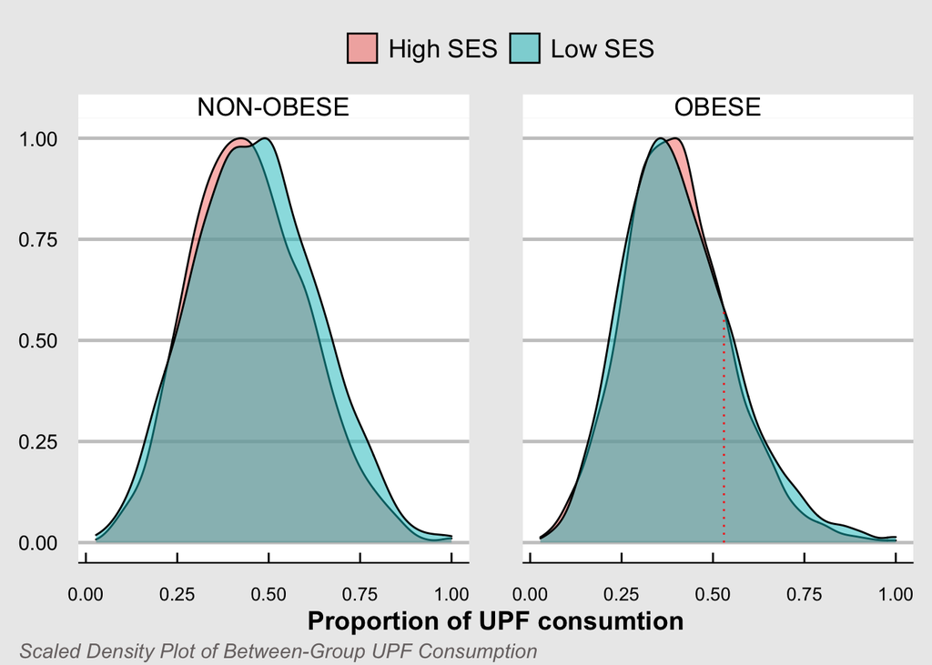

```r
colnames(foodcode_class_ratio)[1] = "ABSPID"
foods_biom_comb = merge(x = foodcode_class_ratio, y = biom_obese, by = "ABSPID", all = TRUE)
foods_biom_comb = foods_biom_comb %>% select(ABSPID, class, ratio, SF2SA1QN, OBESITY) %>% clean_names()
foods_biom_comb = foods_biom_comb %>% drop_na()
foods_biom_comb = foods_biom_comb %>% filter(class == "Ultra-processed")
high_ses = c("3", "4", "5")
low_ses = c("1", "2")
foods_biom_comb = foods_biom_comb %>% mutate(
  new_ses = case_when(
   sf2sa1qn %in% high_ses ~ "High SES",
   sf2sa1qn %in% low_ses ~ "Low SES"
  )
)
foods_biom_comb$new_ses = as.factor(foods_biom_comb$new_ses)

ggplot()+
  xlab("Proportion of UPF consumtion")+
  theme_economist_white()+
  theme(axis.title.y=element_blank(),
        axis.title.x = element_text(color="Black", size=14, face="bold", vjust = -1),
        axis.text.x = element_text(size = 10),
        legend.title=element_blank(),
        plot.title = element_text(hjust = 0.5),
        plot.caption.position = "plot",
        plot.caption = element_text(hjust = 0, face= "italic", vjust = -3.5, colour = "#787272"))+
  theme(panel.spacing = unit(2, "lines"))+
  geom_density(
    data = foods_biom_comb,
    aes(x = ratio, y=..scaled.., group = new_ses, fill = new_ses),
    alpha = 0.5
  )+
  facet_grid(. ~ obesity)+
  geom_segment(data = data.frame(xint=0.5,obesity="OBESE"),
              mapping = aes(x=0.53, y=0,
                            xend=0.53, yend=0.58),
              linetype='dotted',
              color = 'red'
  ) +
  labs(caption = "Scaled Density Plot of Between-Group UPF Consumption")
```

UPF consumption for each person was extracted from previous foodcode_class_ratio dataframe. The figure was plotted for obese people and non-obese people. Within each group, we created a comparison between high SES people and low SES people.

# 7 Aim 2: Whether increased UPF ratio leads to lower protein and increased energy intake ratio among the low-SES group (according to protein leverage hypothesis)

```r
temp1 = foods_biom_comb %>% select("abspid", "ratio", "obesity", "new_ses")
temp2 = tech_nutr %>% select("ABSPID", "PROTT1", "ENERGYT1") %>% clean_names()
p_l_h = merge(x = temp1, y = temp2, by = "abspid", all = TRUE) %>% filter(new_ses == "Low SES")
```

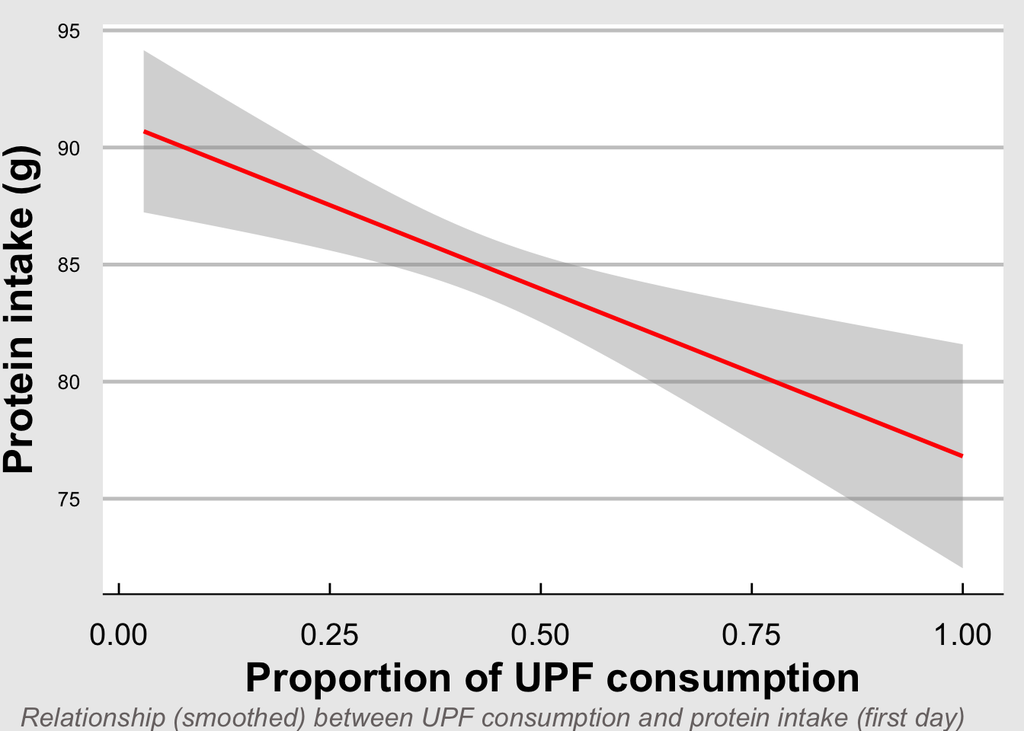

```r
# plot
ggplot(p_l_h, aes(x = ratio, y = prott1)) +
stat_smooth(method = "lm", col = "red")+
theme_economist_white()+
theme(legend.title=element_blank())+
  xlab("Proportion of UPF consumption")+
  ylab("Protein intake (g)")+
theme(axis.title.x = element_text(vjust=-1, size = 20, face = "bold"),
      axis.title.y = element_text(vjust=3, size = 20, face = "bold"),
      plot.title = element_text(vjust=2, size = 30, hjust = 0.5),
      axis.text.x = element_text(size = 15),
      plot.subtitle = element_text(size = 15, hjust = 0.5),
      text = element_text(size=10),
      plot.caption.position = "plot",
      plot.caption = element_text(size = 13, hjust = 0, face= "italic", vjust = -3.5, colour = "#787272"))+
  labs(
    caption = "Relationship (smoothed) between UPF consumption and protein intake (first day)"
  )
```

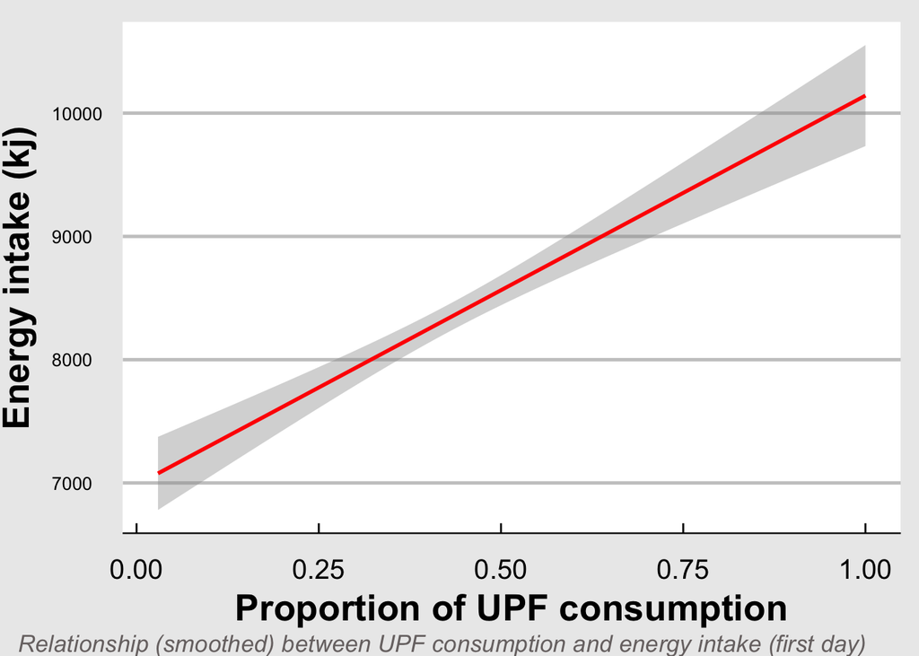

```r
ggplot(p_l_h, aes(x = ratio, y = energyt1)) +
stat_smooth(method = "lm", col = "red")+
theme_economist_white()+
theme(legend.title=element_blank())+
  xlab("Proportion of UPF consumption")+
  ylab("Energy intake (kj)")+
theme(axis.title.x = element_text(vjust=-1, size = 20, face = "bold"),
      axis.title.y = element_text(vjust=3, size = 20, face = "bold"),
      axis.text.x = element_text(size = 15),
      plot.title = element_text(vjust=2, size = 30, hjust = 0.5),
      plot.subtitle = element_text(size = 15, hjust = 0.5),
      text = element_text(size=10),
      plot.caption.position = "plot",
      plot.caption = element_text(size =13, hjust = 0, face= "italic", vjust = -3.5, colour = "#787272"))+
  labs(
    caption = "Relationship (smoothed) between UPF consumption and energy intake (first day)"
  )
```

```r
# ggsave(file="aim2-2.png", width=12, height=7, dpi=300)
```

# 8 Aim 3: Whether UPF consumption is a significant contributor to obesity in low-SES groups

## 8.1 Before building models

```r
foods_obesity = spread(foodcode_class_ratio, key = class, value = ratio) %>% mutate_all(~replace(., is.na(.), 0)) %>% clean_names()
biom_obese = biom_obese %>% clean_names()
biom_obese$"ultra_processed"= foods_obesity$ultra_processed
biom_obese$exlwmbc = as.numeric(biom_obese$exlwmbc)
biom_obese$exlwtbc = as.numeric(biom_obese$exlwtbc)
biom_obese$exlwvbc = as.numeric(biom_obese$exlwvbc)
```

```r
drops <- c("abspid", "phdcmwbc", "phdcmhbc", "whtr")
clrt_biom = biom_obese[ , !(names(biom_obese) %in% drops)]
NA_percent =  clrt_biom %>%
   summarise_each(funs(100*mean(is.na(.)))) %>%
  gather() %>%
  filter(value<30)
clrt_biom = clrt_biom[ , (names(clrt_biom) %in% NA_percent$key)]
clrt_biom = clrt_biom %>% drop_na()
for (i in 1:nrow(clrt_biom)){
  if (clrt_biom$obesity[i] == "OBESE"){
    clrt_biom$obesity[i] = 1
  } else{
    clrt_biom$obesity[i] = 0
  }
}
clrt_biom$obesity = as.factor(clrt_biom$obesity)
```

```r
CLTREE_biom=clrt_biom
clrt_biom = CLTREE_biom %>% filter(sf2sa1qn == 1|sf2sa1qn == 2)
```

## 8.2 CLT_biom

```r
set.seed(3888)
res1 <- rpart(obesity~.,data=clrt_biom,
              parms = list(split="information"))
```

```r
# rpart.plot(res1,
#            type=4,
#            extra=1,
#            main="NCHS  data",
#            cex=0.5)
```

```r
set.seed(3888)
rpart_cont <- rpart.control(cp = 0)
res2 <- rpart(obesity~.,data=clrt_biom,
              control = rpart_cont,
              parms = list(split="information"))
```

```r
df <- data.frame(res2$cptable)
ft <- flextable(df) %>%
  autofit()
ft
```

| CP | nsplit | rel.error | xerror | xstd |
| --- | --- | --- | --- | --- |
| 0.2555994730 | 0 | 1.0000000 | 1.0000000 | 0.03092120 |
| 0.2042160738 | 1 | 0.7444005 | 0.7444005 | 0.02793743 |
| 0.0527009223 | 2 | 0.5401845 | 0.5902503 | 0.02552954 |
| 0.0243741765 | 3 | 0.4874835 | 0.5296443 | 0.02442206 |
| 0.0131752306 | 6 | 0.4084321 | 0.4769433 | 0.02337036 |
| 0.0079051383 | 7 | 0.3952569 | 0.4519104 | 0.02283847 |
| 0.0052700922 | 8 | 0.3873518 | 0.4453228 | 0.02269477 |
| 0.0047430830 | 9 | 0.3820817 | 0.4532279 | 0.02286702 |
| 0.0046113307 | 14 | 0.3583663 | 0.4532279 | 0.02286702 |
| 0.0039525692 | 18 | 0.3399209 | 0.4532279 | 0.02286702 |
| 0.0035133948 | 19 | 0.3359684 | 0.4532279 | 0.02286702 |
| 0.0030742205 | 22 | 0.3254282 | 0.4611331 | 0.02303700 |
| 0.0026350461 | 25 | 0.3162055 | 0.4782609 | 0.02339775 |
| 0.0019762846 | 32 | 0.2977602 | 0.4795784 | 0.02342509 |
| 0.0017566974 | 36 | 0.2898551 | 0.4967062 | 0.02377515 |
| 0.0013175231 | 45 | 0.2687747 | 0.5046113 | 0.02393350 |
| 0.0007905138 | 52 | 0.2595520 | 0.5177866 | 0.02419303 |
| 0.0000000000 | 57 | 0.2555995 | 0.5415020 | 0.02464689 |

```r
kbl(df, caption = "Classification trees based on different complexity parameter (cp)") %>%
  kable_classic(full_width = F) %>%
  row_spec(7, bold = TRUE, color='black') %>%
  add_footnote("Sample size (n) = 2767")
```

Table 8.1: Classification trees based on different complexity parameter (cp)

| CP | nsplit | rel.error | xerror | xstd |
| --- | --- | --- | --- | --- |
| 0.2555995 | 0 | 1.0000000 | 1.0000000 | 0.0309212 |
| 0.2042161 | 1 | 0.7444005 | 0.7444005 | 0.0279374 |
| 0.0527009 | 2 | 0.5401845 | 0.5902503 | 0.0255295 |
| 0.0243742 | 3 | 0.4874835 | 0.5296443 | 0.0244221 |
| 0.0131752 | 6 | 0.4084321 | 0.4769433 | 0.0233704 |
| 0.0079051 | 7 | 0.3952569 | 0.4519104 | 0.0228385 |
| 0.0052701 | 8 | 0.3873518 | 0.4453228 | 0.0226948 |
| 0.0047431 | 9 | 0.3820817 | 0.4532279 | 0.0228670 |
| 0.0046113 | 14 | 0.3583663 | 0.4532279 | 0.0228670 |
| 0.0039526 | 18 | 0.3399209 | 0.4532279 | 0.0228670 |
| 0.0035134 | 19 | 0.3359684 | 0.4532279 | 0.0228670 |
| 0.0030742 | 22 | 0.3254282 | 0.4611331 | 0.0230370 |
| 0.0026350 | 25 | 0.3162055 | 0.4782609 | 0.0233978 |
| 0.0019763 | 32 | 0.2977602 | 0.4795784 | 0.0234251 |
| 0.0017567 | 36 | 0.2898551 | 0.4967062 | 0.0237752 |
| 0.0013175 | 45 | 0.2687747 | 0.5046113 | 0.0239335 |
| 0.0007905 | 52 | 0.2595520 | 0.5177866 | 0.0241930 |
| 0.0000000 | 57 | 0.2555995 | 0.5415020 | 0.0246469 |

<sup>a</sup> Sample size (n) = 2767

Use the `rpart.control` function to set the value of cp to zero. This brought us a full tree without performing any pruning using cp. We then refit the tree based on different cp. The one that returns smallest error is around 0.005.

```r
cpvals <- res2$cptable[,1]
nsplit <- res2$cptable[,2]
xerror <- res2$cptable[,4]
minpos <- min(seq_along(xerror)[xerror == min(xerror)])
```

```r
res3 <- prune.rpart(res2, cp = res2$cptable[7])
# rpart.plot(res3,type=4,extra=1, main="NCHS  data",cex=0.55)
```

```r
g <- vip(res3, num_features = 15) + theme_bw()
df <- as.data.frame(g$data)
ft <- flextable(df) %>% autofit()
tree1 = as.data.frame(g$data)
```

```r
for (i in 1:nrow(tree1)){
  des = dic_full %>% filter(tolower(Variable) == tree1$Variable[i]) %>% drop_na(Description)
  tree1$Indicator[i] = des$Description[1]
}
tree1 = tree1[,c(3,2,1)]
tree1$Indicator[11] = "Ultra Processed Foods consumption"
colnames(tree1)[1] = "Variable Description"

kbl(tree1[,-3], align = "l",color = 'white', caption = "The first 15 important variables from classification trees based on the cp that returns smallest error") %>%
  kable_classic(full_width = F) %>%
  row_spec(11, bold = TRUE,color = '#000000') %>%
    add_footnote("Sample size (n) = 2767")
```

Table 8.2: The first 15 important variables from classification trees based on the cp that returns smallest error

| Variable Description | Importance |
| --- | --- |
| Body mass index (BMI) | 644.860828 |
| Measured weight (kg) | 411.426978 |
| Self-perceived body mass | 304.042096 |
| Age of person (y) | 147.049740 |
| Systolic blood pressure (mmHg) | 121.230744 |
| Diastolic blood pressure (mmHg) | 77.915328 |
| Sex of person | 46.369970 |
| Equivalised income of household: deciles | 29.117645 |
| Whether has hypertensive disease | 26.021871 |
| Whether has high cholesterol | 16.210346 |
| Ultra Processed Foods consumption | 10.448045 |
| Whether has diabetes mellitus | 6.612115 |
| Total mins undertaken physical activity in last week | 3.107600 |
| Sleep duration in minutes on day prior to interview | 1.893641 |
| Whether currently on a diet | 1.682391 |

<sup>a</sup> Sample size (n) = 2767

Variable improtance was extracted from the tree built on the cp which returns the smallest error.

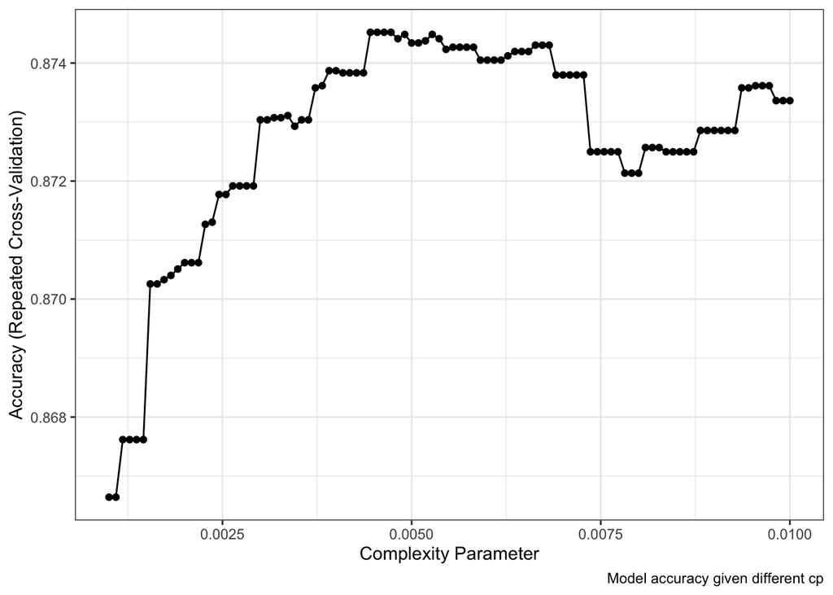

```r
# caret cross validation results
n_grid <- 100
tuneGrid <- expand.grid(cp = seq(0.01, 0.001, length=n_grid))

res4 <- train(
  obesity ~ .,
  data = clrt_biom,
  method = "rpart",
  trControl = trainControl(method = "repeatedcv",
                           number = 10,
                           repeats = 10),
  tuneGrid = tuneGrid)

ggplot(res4) +
  theme_bw()+
  labs(caption = "Model accuracy given different cp")
```

10-fold cross validation was used to generate the accuracy figure above.

```r
df <- as.data.frame(res4$results)
ft <- flextable(df) %>% autofit()
```

```r
max_val <- which.max(res4$results$Accuracy)
opt_cv  <- res4$results$cp[max_val]
```

```r
res5 <- prune.rpart(res2, cp = opt_cv)
# rpart.plot(res5,type=4,extra=1, main="NCHS  data",cex=0.55)
```

```r
g <- vip(res5, num_features = 15) + theme_bw()
df <- as.data.frame(g$data)
ft <- flextable(df) %>% autofit()
tree2 = g$data
```

```r
for (i in 1:nrow(tree2)){
  des = dic_full %>% filter(tolower(Variable) == tree2$Variable[i]) %>% drop_na(Description)
  tree2$Indicator[i] = des$Description[1]
}
tree2 = tree2[,c(3,2,1)]
tree2$Indicator[11] = "Ultra Processed Foods consumption"
colnames(tree2)[1] = "Variable Description"
kbl(tree2[,-3], align = "l",color = 'white') %>%
  kable_classic(full_width = F) %>%
  row_spec(11, bold = T,color = 'black')
```

| Variable Description | Importance |
| --- | --- |
| Body mass index (BMI) | 662.488970 |
| Measured weight (kg) | 436.490008 |
| Self-perceived body mass | 306.132241 |
| Age of person (y) | 160.414668 |
| Systolic blood pressure (mmHg) | 123.860346 |
| Diastolic blood pressure (mmHg) | 79.699978 |
| Sex of person | 52.699506 |
| Equivalised income of household: deciles | 37.194354 |
| Whether has hypertensive disease | 26.021871 |
| Whether has high cholesterol | 16.210346 |
| Ultra Processed Foods consumption | 14.055211 |
| Whether has diabetes mellitus | 7.502640 |
| Total mins undertaken physical activity in last week | 7.377759 |
| Usual daily serves of vegetables | 6.954006 |
| Usual daily serves of fruit | 3.501860 |

```r
tree_combine = cbind(tree1, tree2)
colnames(tree_combine) = c("Variable Description (Model 1)", "Importance (Model 1)", "Deleted",
                           "Variable Description (Model 2)", "Importance (Model 2)", "Deleted2")
tree_combine = tree_combine %>% select(-c(Deleted2, Deleted))
kbl(tree_combine, align = "l",color = 'white') %>%
  kable_classic(full_width = F) %>%
  row_spec(11, bold = T,color = 'black') %>%
  add_footnote(c("Sample size (n) = 2767",
                 "Three variables that descripe ID, weight and height of the sample were removed",
                 "Model 1: The model given by the complexity parameter that returns the smallest error.",
                "Model 2: The model given by 10-fold cross validation"
                ))
```

| Variable Description (Model 1) | Importance (Model 1) | Variable Description (Model 2) | Importance (Model 2) |
| --- | --- | --- | --- |
| Body mass index (BMI) | 644.860828 | Body mass index (BMI) | 662.488970 |
| Measured weight (kg) | 411.426978 | Measured weight (kg) | 436.490008 |
| Self-perceived body mass | 304.042096 | Self-perceived body mass | 306.132241 |
| Age of person (y) | 147.049740 | Age of person (y) | 160.414668 |
| Systolic blood pressure (mmHg) | 121.230744 | Systolic blood pressure (mmHg) | 123.860346 |
| Diastolic blood pressure (mmHg) | 77.915328 | Diastolic blood pressure (mmHg) | 79.699978 |
| Sex of person | 46.369970 | Sex of person | 52.699506 |
| Equivalised income of household: deciles | 29.117645 | Equivalised income of household: deciles | 37.194354 |
| Whether has hypertensive disease | 26.021871 | Whether has hypertensive disease | 26.021871 |
| Whether has high cholesterol | 16.210346 | Whether has high cholesterol | 16.210346 |
| Ultra Processed Foods consumption | 10.448045 | Ultra Processed Foods consumption | 14.055211 |
| Whether has diabetes mellitus | 6.612115 | Whether has diabetes mellitus | 7.502640 |
| Total mins undertaken physical activity in last week | 3.107600 | Total mins undertaken physical activity in last week | 7.377759 |
| Sleep duration in minutes on day prior to interview | 1.893641 | Usual daily serves of vegetables | 6.954006 |
| Whether currently on a diet | 1.682391 | Usual daily serves of fruit | 3.501860 |

<sup>a</sup> Sample size (n) = 2767  
<sup>b</sup> Three variables that descripe ID, weight and height of the sample were removed  
<sup>c</sup> Model 1: The model given by the complexity parameter that returns the smallest error.  
<sup>d</sup> Model 2: The model given by 10-fold cross validation

Similarly, the variable importance was extracted from the model which was built on the cp suggested by 10-fold cross validation. And we put these importance tables together.

## 8.3 Random Forest

```r
# number of features
n_features <- length(setdiff(names(clrt_biom), "obesity"))

# train a default random forest model
res6 <- ranger(
  obesity ~ .,
  data = clrt_biom,
  mtry = floor(n_features / 3),
  respect.unordered.factors = "order",
  seed = 123
)

# get OOB error
prediction_error <- res6$prediction.error
```

```r
# create hyperparameter grid
hyper_grid <- expand.grid(
  mtry = floor(n_features * c(.05, .15, .25, .333, .4)),
  min.node.size = c(1, 3, 5),
  replace = c(TRUE, FALSE),
  sample.fraction = c(.5, .63, .8),
  error = NA
)

# execute full cartesian grid search
for(i in seq_len(nrow(hyper_grid))) {
  # fit model for ith hyperparameter combination
  fit <- ranger(
    formula         = obesity ~ .,
    data            = clrt_biom,
    num.trees       = n_features * 5,
    mtry            = hyper_grid$mtry[i],
    min.node.size   = hyper_grid$min.node.size[i],
    replace         = hyper_grid$replace[i],
    sample.fraction = hyper_grid$sample.fraction[i],
    verbose         = FALSE,
    seed            = 123,
    respect.unordered.factors = 'order',
  )
  # export OOB error
  hyper_grid$error[i] <- fit$prediction.error
}
mean(hyper_grid$error)
```

```
## [1] 0.1253142
```

A hyperparameter grid was firstly built. Followed by a full cartesian grid search, we got a total of 90 models and its corresponding error. The mean of error is then obtainable and used to see if random forests worked well.

```r
# re-run model with impurity-based variable importance
rf_impurity <- ranger(
  formula = obesity ~ .,
  data = clrt_biom,
  num.trees = 2000,
  mtry = 12,
  min.node.size = 5,
  sample.fraction = .80,
  replace = FALSE,
  importance = "impurity",
  respect.unordered.factors = "order",
  verbose = FALSE,
  seed  = 123
)

# re-run model with permutation-based variable importance
rf_permutation <- ranger(
  formula = obesity ~ .,
  data = clrt_biom,
  num.trees = 2000,
  mtry = 12,
  min.node.size = 5,
  sample.fraction = .80,
  replace = FALSE,
  importance = "permutation",
  respect.unordered.factors = "order",
  verbose = FALSE,
  seed  = 123
)
```

```r
p1 <- vip::vip(rf_impurity, num_features = 15, bar = FALSE) + theme_bw()
p2 <- vip::vip(rf_permutation, num_features = 15, bar = FALSE) + theme_bw()

df1 <- as.data.frame(p1$data)
df1 <- flextable(df1) %>% autofit()

df2 <- as.data.frame(p2$data)
df2 <- flextable(df2) %>% autofit()
tree3 = as.data.frame(p1$data)
tree4 = as.data.frame(p2$data)
# gridExtra::grid.arrange(df1, df2, nrow = 1)
```

```r
for (i in 1:nrow(tree3)){
  des = dic_full %>% filter(tolower(Variable) == tree3$Variable[i]) %>% drop_na(Description)
  tree3$Indicator[i] = des$Description[1]
}
tree3 = tree3[,c(3,2,1)]
tree3$Indicator[6] = "Ultra Processed Foods consumption"

# kbl(tree3[,-3], align = "l",color = 'white',
#     caption = "Table 1.2 The first 15 important variables from the model whose importance is impurity-based") %>%
#   kable_classic(full_width = F) %>%
#   row_spec(6, bold = T,color = 'red') %>%
#   save_kable("Table1.2.png",zoom = 4)

for (i in 1:nrow(tree4)){
  des = dic_full %>% filter(tolower(Variable) == tree3$Variable[i]) %>% drop_na(Description)
  tree4$Indicator[i] = des$Description[1]
}
tree4 = tree4[,c(3,2,1)]
tree4$Indicator[6] = "Ultra Processed Foods consumption"

tree_combine = cbind(tree3, tree4)
colnames(tree_combine) = c("Variable Description (Model 1)", "Importance (Model 1)", "Deleted1",
                           "Variable Description (Model 2)", "Importance (Model 2)", "Deleted2")
tree_combine = tree_combine %>% select(-c(Deleted1, Deleted2))
kbl(tree_combine, align = "l",color = 'white') %>%
  kable_classic(full_width = F) %>%
  row_spec(6, bold = T,color = 'black') %>%
  add_footnote(c("Sample size (n) = 2767",
                 "Three variables that descripe ID, weight and height of the sample were removed",
                 "Model 1: Impurity-based variable importance",
                "Model 2: Permutation-based variable importance"
                ))
```

| Variable Description (Model 1) | Importance (Model 1) | Variable Description (Model 2) | Importance (Model 2) |
| --- | --- | --- | --- |
| Body mass index (BMI) | 335.626274 | Body mass index (BMI) | 0.1780135 |
| Age of person (y) | 100.671928 | Age of person (y) | 0.0375505 |
| Measured weight (kg) | 66.143285 | Measured weight (kg) | 0.0261236 |
| Self-perceived body mass | 65.245546 | Self-perceived body mass | 0.0130081 |
| Systolic blood pressure (mmHg) | 25.854859 | Systolic blood pressure (mmHg) | 0.0124504 |
| Ultra Processed Foods consumption | 23.745985 | Ultra Processed Foods consumption | 0.0043899 |
| Diastolic blood pressure (mmHg) | 22.282653 | Diastolic blood pressure (mmHg) | 0.0042888 |
| Sex of person | 22.155482 | Sex of person | 0.0027211 |
| Total mins undertaken physical activity in last week | 21.443119 | Total mins undertaken physical activity in last week | 0.0024007 |
| Total mins spent sitting or lying down | 20.552634 | Total mins spent sitting or lying down | 0.0019161 |
| Equivalised income of household: deciles | 20.418306 | Equivalised income of household: deciles | 0.0012473 |
| Sleep duration in minutes on day prior to interview | 15.329497 | Sleep duration in minutes on day prior to interview | 0.0010171 |
| Total mins undertaken vigorous physical activity in last week | 12.399680 | Total mins undertaken vigorous physical activity in last week | 0.0006119 |
| Usual daily serves of vegetables | 9.652639 | Usual daily serves of vegetables | 0.0005280 |
| Usual daily serves of fruit | 9.430152 | Usual daily serves of fruit | 0.0005108 |

<sup>a</sup> Sample size (n) = 2767  
<sup>b</sup> Three variables that descripe ID, weight and height of the sample were removed  
<sup>c</sup> Model 1: Impurity-based variable importance  
<sup>d</sup> Model 2: Permutation-based variable importance

We reran the model The variable importance was then extracted as above. Note that the left one was impurity-based and the right one was permutation-based.

# 9 Log regression

## 9.1 10-fold cv

```r
name_variable = c(tree1$Variable[1:rownames(tree1[match("ultra_processed",tree1$Variable),])],
                  tree2$Variable[1:rownames(tree2[match("ultra_processed",tree2$Variable),])],
                  tree3$Variable[1:rownames(tree3[match("ultra_processed",tree3$Variable),])],
                  tree4$Variable[1:rownames(tree4[match("ultra_processed",tree4$Variable),])]) %>%
  as.data.frame() %>% distinct()
name_variable[nrow(name_variable)+1,] = "obesity"
name_variable[nrow(name_variable)+2,] = "sf2sa1qn"
new_log_set = CLTREE_biom [ , (names(CLTREE_biom) %in% name_variable$.)]
new_log_set = new_log_set %>% filter(sf2sa1qn == 1|sf2sa1qn == 2)
```

```r
df = new_log_set
df <- df[ , c(1:13, 15, 14)]
XX <- df[, 1:14]
yy <- df[, 15]
```

```r
cv_penLogistic1 <- function(yy, XX, method = c("vanilla",
                                        "fowardAIC",
                                          "forwardBIC",
                                        "stepwiseAIC",
                                        "stepwiseBIC",
                                        "firth",
                                        "ridge",
                                        "lasso"),
                           folds = 10,
                           repeats = 10,
                           seed = 1)
{
  set.seed(seed)
  n <- nrow(XX)

  error_mat <- matrix(NA, n, repeats)
  dat <- data.frame(y = yy, X = XX)
  for (r in 1:repeats)
  {
    sets <- sample(rep(1:folds,n)[1:n],n)
    for(i in 1:folds){
      testSet  <- which(sets == i)
      trainSet <- (1:n)[-testSet]
      testData    <- dat[testSet, ]
      trainData   <- dat[trainSet, ]

      if (method == "vanilla") {
        model       <- glm(y~.,family = binomial, data = trainData)
      }

      if (method %in% c("fowardAIC", "forwardBIC", "stepwiseAIC", "stepwiseBIC"))
      {
        null = glm(y~1,data = trainData, family = binomial)
        full = glm(y~.,data = trainData, family = binomial)
      }

      if (method == "fowardAIC") {
        model <- step(null, scope = list(lower = null, upper = full), k = 2, trace = 0)
      }

      if (method == "forwardBIC") {
        model <- step(null, scope = list(lower = null, upper = full), k = log(n), trace = 0)
      }

      if (method == "stepwiseAIC") {
        model <- step(full, k = 2, trace = 0)
      }

      if (method == "stepwiseBIC") {
        model <- step(full, k = log(n), trace = 0)
      }

      if (method == "ridge") {
        vars_name_logset <- trainData %>%
          select(-y) %>%
          colnames() %>%
          str_c(collapse = "+")
        model_string <- paste("y  ~",vars_name_logset)
        x_train <- model.matrix(as.formula(model_string), trainData)
        model <- cv.glmnet(x=x_train,y = trainData$y, family = "binomial", alpha=0)
        # model <- cv.glmnet(data.matrix(trainData[, -1]), trainData$y,
        #                    alpha = 0, family = "binomial")
      }

      if (method == "lasso") {
        vars_name_logset <- trainData %>%
          select(-y) %>%
          colnames() %>%
          str_c(collapse = "+")
        model_string <- paste("y  ~",vars_name_logset)
        x_train <- model.matrix(as.formula(model_string), trainData)
        model <- cv.glmnet(x=x_train,y = trainData$y, family = "binomial", alpha=1)

        # model <- cv.glmnet(data.matrix(trainData[, -1]), trainData$y,
        #                    alpha = 1, family = "binomial")
      }
      if (method == "lassolmin") {
        vars_name_logset <- trainData %>%
          select(-y) %>%
          colnames() %>%
          str_c(collapse = "+")
        model_string <- paste("y  ~",vars_name_logset)
        x_train <- model.matrix(as.formula(model_string), trainData)
        model <- cv.glmnet(x=x_train,y = trainData$y, family = "binomial", alpha=1)

        # model <- cv.glmnet(data.matrix(trainData[, -1]), trainData$y,
        #                    alpha = 1, family = "binomial")
      }

      if (method == "firth") {
        model <- brglm(y~., data=trainData)
      }

      if (method == "lassolmin"){
         newX <- model.matrix(~.-y,data=testData)
         res <- predict(model, newx = newX, s = "lambda.min")
         testProb <- 1/(1 + exp(-res))
      } else{
      if (!(method %in% c("ridge", "lasso"))) {
        testProb <- predict(model, testData, type = "response")
      }

      if (method %in% c("ridge","lasso") ) {
         newX <- model.matrix(~.-y,data=testData)
         res <- predict(model, newx = newX, s = "lambda.1se")
        # res <- predict(model, newx = data.matrix(testData[,-1]), s = "lambda.1se")
        testProb <- 1/(1 + exp(-res))
      }}

      testPred <- round(testProb)
      errs <- as.numeric(testData$y != testPred)
      error_mat[testSet,r] <- errs
    }
  }
  result <- list(error_mat, model)
  return(result)
}
```

```r
# All results below in this chunck has been saved as Rdata to reduce the time of reproducing
# repeats <- 10
# res11 <- cv_penLogistic1(yy, XX, method = "vanilla", repeats = repeats)
# res12 <- cv_penLogistic1(yy, XX, method = "fowardAIC", repeats = repeats)
# res13 <- cv_penLogistic1(yy, XX, method = "forwardBIC", repeats = repeats)
# res14 <- cv_penLogistic1(yy, XX, method = "stepwiseAIC", repeats = repeats)
# res15 <- cv_penLogistic1(yy, XX, method = "stepwiseBIC", repeats = repeats)
# res16 <- cv_penLogistic1(yy, XX, method = "ridge", repeats = repeats)
# res17 <- cv_penLogistic1(yy, XX, method = "lasso", repeats = repeats)
# res175 <- cv_penLogistic1(yy, XX, method = "lassolmin", repeats = repeats)
# res18 <- cv_penLogistic1(yy, XX, method = "firth", repeats = repeats)
load(here("data", "res11.Rdata"))
load(here("data", "res12.Rdata"))
load(here("data", "res13.Rdata"))
load(here("data", "res14.Rdata"))
load(here("data", "res15.Rdata"))
load(here("data", "res16.Rdata"))
load(here("data", "res17.Rdata"))
load(here("data", "res175.Rdata"))
load(here("data", "res18.Rdata"))
```

```r
tab1 <- cbind(
  apply(res11[[1]], 2, mean),
  apply(res12[[1]], 2, mean),
  apply(res13[[1]], 2, mean),
  apply(res14[[1]], 2, mean),
  apply(res15[[1]], 2, mean),
  apply(res16[[1]], 2, mean),
  apply(res17[[1]], 2, mean),
  apply(res175[[1]], 2, mean),
  apply(res18[[1]], 2, mean))

colnames(tab1) <- c("Full",
                   "Foward AIC",
                   "Foward BIC",
                   "Stepwise AIC",
                   "StepwiseBIC",
                   "Ridge",
                   "Lasso.min",
                   "Lasso.1se",
                   "Firth")

tab2 = tab1 %>% as.data.frame()
tab2 = tab2 %>% gather()
tab2$key[tab2$key == "StepwiseBIC"] <- "BackwardBIC"
tab2$key[tab2$key == "Stepwise AIC"] <- "BackwardAIC"
```

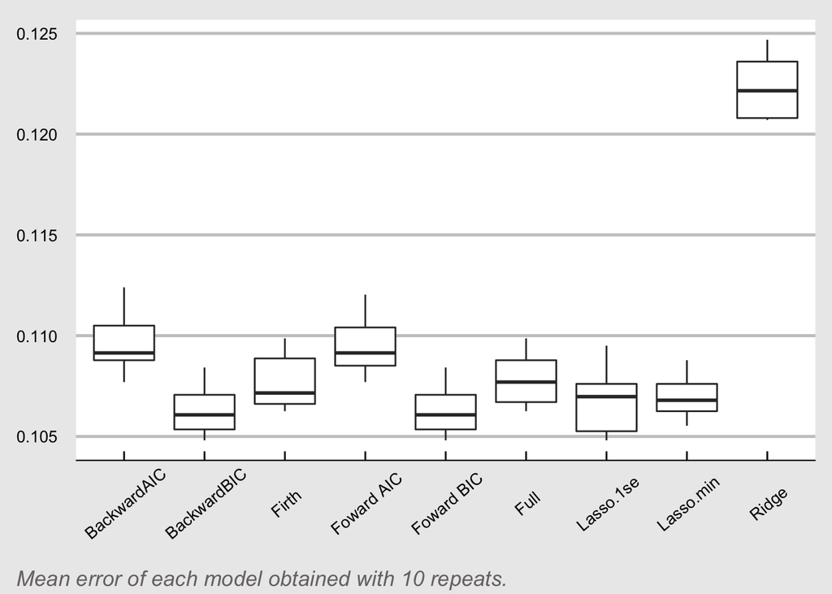

```r
ggplot()+
  theme_economist_white()+
  geom_boxplot(data = tab2,
               aes(x=key,
                   y=value)) +
  labs(caption = "Mean error of each model obtained with 10 repeats.")+
  theme(axis.title.y = element_blank(),
        axis.title.x = element_blank(),
        axis.text.x = element_text(size = 10, angle = 40, vjust = 0.7),
        plot.title = element_text(vjust=2, size = 20, hjust = 0.5),
        plot.subtitle = element_text(size = 15, hjust = 0.5),
        text = element_text(size=10),
        plot.caption.position = "plot",
        plot.caption = element_text(size =13, hjust = 0, face= "italic", vjust = -2.5, colour = "#787272"))
```

```r
 # ggsave(file="log.png", width=12, height=7, dpi=300)
```

## 9.2 The best model

```r
new_log_set$obesity = as.character(new_log_set$obesity)
new_log_set$obesity = as.integer(new_log_set$obesity)
res <- glm(obesity~.,data=new_log_set,family=binomial)
```

```r
# Warning: This chuck of code takes 5-10 mins to run
null = glm(obesity~1,data=new_log_set,family=binomial)
full = glm(obesity~.,data=new_log_set,family=binomial)
n = nrow(new_log_set)

# stepwise from full model using BIC
stepBICfull <- step(full,k=log(n))

# stepwise from full model using AIC
stepAICfull <- step(full,k=2)

# stepwise from null model using BIC
stepBICnull <- step(null,scope=list(lower=null,upper=full),k=log(n))

# stepwise from null model using AIC
stepAICnull <- step(null,scope=list(lower=null,upper=full),k=2)
```

```r
names(stepBICfull$coefficients) = c("Intercept", "BMI", "Age", "Measured weight", "Physical activity", "Sex")
names(stepBICnull$coefficients) = c("Intercept", "BMI", "Age",  "Sex", "Measured weight", "Physical activity")
tab_model(stepBICfull,  auto.label = FALSE)
```

|  | obesity |  |  |
| --- | --- | --- | --- |
| Predictors | Odds Ratios | CI | p |
| Intercept | 0.00 | 0.00 – 0.00 | **<0.001** |
| BMI | 2.43 | 2.20 – 2.68 | **<0.001** |
| Age | 1.06 | 1.05 – 1.07 | **<0.001** |
| Measured weight | 0.94 | 0.92 – 0.96 | **<0.001** |
| Physical activity | 1.00 | 0.99 – 1.00 | **<0.001** |
| Sex | 2.93 | 2.01 – 4.29 | **<0.001** |
| Observations | 2767 |  |  |
| R<sup>2</sup> Tjur | 0.616 |  |  |

```r
tab_model(stepBICnull,  auto.label = FALSE)
```

|  | obesity |  |  |
| --- | --- | --- | --- |
| Predictors | Odds Ratios | CI | p |
| Intercept | 0.00 | 0.00 – 0.00 | **<0.001** |
| BMI | 2.43 | 2.20 – 2.68 | **<0.001** |
| Age | 1.06 | 1.05 – 1.07 | **<0.001** |
| Sex | 2.93 | 2.01 – 4.29 | **<0.001** |
| Measured weight | 0.94 | 0.92 – 0.96 | **<0.001** |
| Physical activity | 1.00 | 0.99 – 1.00 | **<0.001** |
| Observations | 2767 |  |  |
| R<sup>2</sup> Tjur | 0.616 |  |  |

The model was then available. Forward BIC and backward BIC returned same model.

# 10 netural network

```r
temp_tree4 = tree4
temp_tree4 = temp_tree4[,c(3,2,1)]
temp_tree4$Indicator = "NA"
temp_tree4 = temp_tree4[,c(3,2,1)]
tree2 = as.data.frame(tree2)
colnames(temp_tree4)[1] = "Variable Description"
colnames(tree3)[1] = "Variable Description"
tree1234 = rbind(tree1[1:which(tree1$Variable == "ultra_processed"),],
       tree2[1:which(tree2$Variable == "ultra_processed"),],
       tree3[1:which(tree3$Variable == "ultra_processed"),],
      temp_tree4[1:which(temp_tree4$Variable == "ultra_processed"),]) %>% distinct(Variable)
nnw_set = biom_obese[ , (names(biom_obese) %in% c(tree1234$Variable, "obesity", "sf2sa1qn"))] %>% drop_na()
nnw_set = nnw_set %>% filter(sf2sa1qn == 1|sf2sa1qn ==2) %>% select(-sf2sa1qn)
```

```r
# map_chr(nnw_set_dummy,class)
nnw_set_dummy = nnw_set
nnw_set_dummy = data.frame(nnw_set[ , ! colnames(nnw_set) %in% "sex"],       # Create dummy data
                           model.matrix( ~ sex - 1, nnw_set))

nnw_set_dummy = data.frame(nnw_set_dummy[ , ! colnames(nnw_set_dummy) %in% "sabdyms"],       # Create dummy data
                         model.matrix( ~ sabdyms - 1, nnw_set_dummy)) %>% select(-c(hcholbc,hypbc))
# nnw_set_dummy = data.frame(nnw_set_dummy[ , ! colnames(nnw_set_dummy) %in% "incdec"],       # Create dummy data
#                          model.matrix( ~ incdec - 1, nnw_set_dummy)) %>% select(-c(incdec98,incdec99,))
nnw_set_dummy = nnw_set_dummy %>% as.tibble()
nnw_set_dummy = nnw_set_dummy %>% select(obesity, everything())
nnw_set_dummy = nnw_set_dummy %>% select(-c(incdec,sabdyms0,sabdyms4,sabdyms8,sabdyms9))
nnw_set_dummy= nnw_set_dummy %>% mutate(
  obesity = case_when(
    obesity == "OBESE" ~ 1,
    obesity == "NON-OBESE" ~0
  )
)
nnw_set_dummy$obesity = as.factor(nnw_set_dummy$obesity)
```

```r
mystd <- function(x) {
  x <- (x-mean(x, na.rm=TRUE))/sd(x, na.rm=TRUE)
}
nnw_set_dummy_std <- nnw_set_dummy %>%
  mutate_if(is.numeric, list(mystd))

set.seed(20190426)
tr_indx <- createDataPartition(nnw_set_dummy$obesity)$Resample1
nnw_set_dummy_tr <- nnw_set_dummy_std[tr_indx,]
nnw_set_dummy_ts <- nnw_set_dummy_std[-tr_indx,]
```

```r
load(here("data", "neural.Rdata"))
pred <- stats::predict(nnw_set_dummy_nn, nnw_set_dummy_ts)
nnw_set_dummy_ts$pred <- ifelse(pred[,1] > 0.5, 1, 0)
nnw_set_dummy_ts$pred_log = ifelse(nnw_set_dummy_ts$pred == nnw_set_dummy_ts$obesity, "TRUE", "FALSE")
confusion_table = table(nnw_set_dummy_ts$obesity, nnw_set_dummy_ts$pred_log)
rownames(confusion_table) = c("NON-OBESE", "OBESE")

kbl(confusion_table) %>%
  kable_classic(full_width = F) %>%
  add_footnote("Sample size (n) = 2892")
```

|  | FALSE | TRUE |
| --- | --- | --- |
| NON-OBESE | 225 | 197 |
| OBESE | 594 | 430 |

<sup>a</sup> Sample size (n) = 2892

We fitted the neural network with only 1 hidden layer and 6 neurons. Half of the data was used as the test set and the other part was used to train the model. A threshold of 0.5 was selected and each value which was greater than 0.5 would be seen as 1 and 0 if otherwise. 1 represents obesity and 0 represents non-obesity. Then the prediction test was available. The confusion matrix above was established based on the prediction results.

```r
nnw_set_dummy_ts$predy <- pred[,1]
```

```r
wgts1 <- nnw_set_dummy_nn$weights[[1]][[1]]
rownames(wgts1) <- c("intercept", colnames(nnw_set_dummy_tr[,-1]))
colnames(wgts1) <- paste0("s", 1:6)
```

```r
wgts2 <- nnw_set_dummy_nn$weights[[1]][[2]]
rownames(wgts2) <- c("intercept", paste0("s", 1:6))
colnames(wgts2) <- c("NON-OBESE", "OBESE")
```

```r
logit <- function(x) {
  1/(1+exp(-x))
}

neurons <- as.matrix(nnw_set_dummy_tr[,-1])%*%wgts1[-1,] + rep(wgts1[1,], nrow(nnw_set_dummy_tr))
neurons <- as_tibble(neurons) %>%
  mutate_at(vars(contains("s")), logit) %>%
 bind_cols(nnw_set_dummy_tr[,1]) %>%
  gather(neuron, prediction, -obesity)
```

[figure not shown]

```r
wgts1_df <- as_tibble(wgts1[-1,]) %>%
  mutate_all(., abs) %>%
  mutate(var=rownames(wgts1[-1,])) %>%
  gather(neuron,
         weight,
         -var)

wgts1_df = wgts1_df %>% mutate(
  var = case_when(
    var == "bmisc"~ "BMI",
    var == "agec"~"Age",
    var == "phdkgwbc"~"Measured weight",
    var == "exlwtbc"~"Physical activity",
    var == "exlwvbc"~"Vigorous Physical activity",
    var == "diastol"~"Diastolic blood pressure",
    var == "systol"~"Systolic blood pressure",
    var == "ultra_processed"~"UPF consumption",
    var == "sex1"~"Male",
    var == "sex2"~"Female",
    var == "sabdyms1"~"Acceptable weight",
    var == "sabdyms2"~"Underweight",
    var == "sabdyms3"~"Overweight"
  )
)
ggplot(wgts1_df,
       aes(x=var,
           y=weight)) +
  geom_col() +
  facet_wrap(~neuron,
             ncol=2,
             scales="free_x") +
  coord_flip()+
  labs(
    y = "Variable Importance",
    caption = "Importance of each variable in each neuron"
  )+
  theme(
    axis.title.y = element_blank(),
    axis.text.y = element_text(size = 15),
    strip.text = element_text(size = 15)
  )
```

Followed by standardisation of our input variables, we divided the data into 2 samples, one of which would be used to train the data and the other one was used to test the model. Since all variables had been standardised, the weights in the neural network could be seen as the importance.

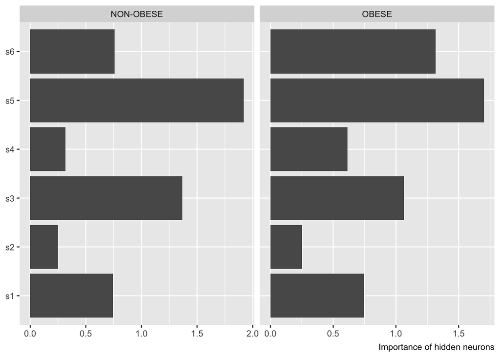

```r
wgts2_df <- as_tibble(wgts2[-1,]) %>%
  mutate_all(., abs) %>%
  mutate(var=rownames(wgts2[-1,])) %>%
  gather(neuron,
         weight,
         -var)
ggplot(wgts2_df,
       aes(x=var,
           y=weight)) +
  geom_col() +
  facet_wrap(~neuron,
             ncol=2,
             scales="free_x") +
  coord_flip() +
  theme(
    axis.title.y = element_blank(),
    axis.title.x = element_blank()
  )+
  labs(caption = "Importance of hidden neurons")
```

Same as above, the weight of each neuron could be seen as the importance indicator since the values in the dataframe had all been standardised.

# 11 K-means clustering

```r
drops <- c("phdcmwbc", "phdcmhbc", "whtr")
clrt_biom_knn = biom_obese[ , !(names(biom_obese) %in% drops)]
NA_percent =  clrt_biom_knn %>%
   summarise_each(funs(100*mean(is.na(.)))) %>%
  gather() %>%
  filter(value<30)
clrt_biom_knn = clrt_biom_knn[ , (names(clrt_biom_knn) %in% NA_percent$key)]
clrt_biom_knn = clrt_biom_knn %>% drop_na()
for (i in 1:nrow(clrt_biom_knn)){
  if (clrt_biom_knn$obesity[i] == "OBESE"){
    clrt_biom_knn$obesity[i] = 1
  } else{
    clrt_biom_knn$obesity[i] = 0
  }
}
clrt_biom_knn$obesity = as.factor(clrt_biom_knn$obesity)
```

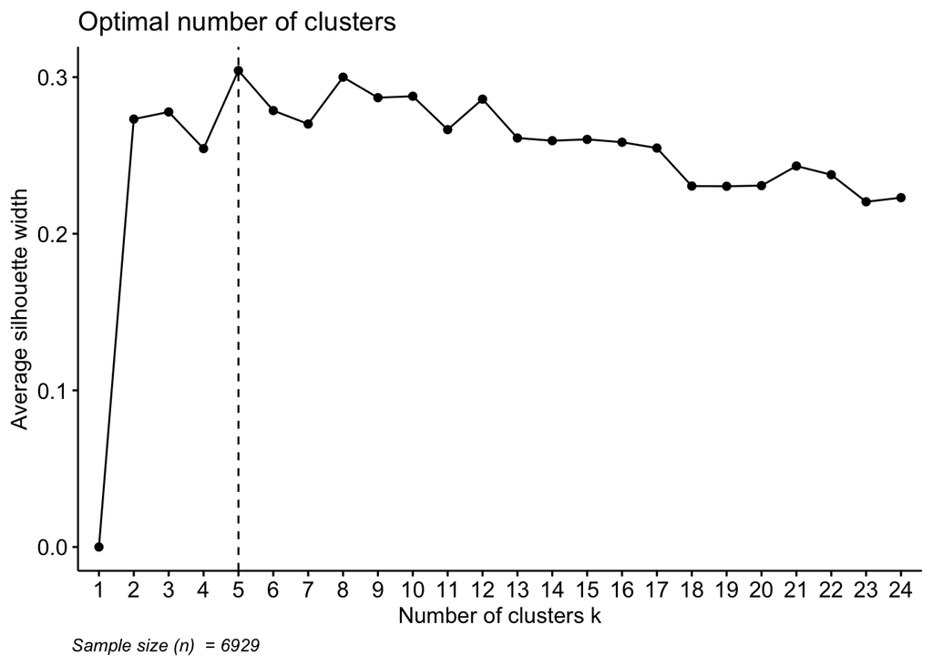

```r
kcluster_biom=clrt_biom_knn
kcluster_biom = kcluster_biom %>% select(bmisc, agec, phdkgwbc, sex, sabdyms,systol, diastol)
kcluster_biom$sabdyms = as.character(kcluster_biom$sabdyms)
kcluster_biom$sabdyms = as.factor(kcluster_biom$sabdyms)

kcluster_biom = data.frame(kcluster_biom[ , ! colnames(kcluster_biom) %in% "sex"],       # Create dummy data
                           model.matrix( ~ sex - 1, kcluster_biom))
kcluster_biom = data.frame(kcluster_biom[ , ! colnames(kcluster_biom) %in% "sabdyms"],       # Create dummy data
                           model.matrix( ~ sabdyms - 1, kcluster_biom))
kcluster_biom = kcluster_biom %>% drop_na()
scaled_set = kcluster_biom %>% scale()

fviz_nbclust(scaled_set, kmeans, method = "silhouette", k.max = 24, linecolor = 'black') +
  labs(caption = "Sample size (n)  = 6929")+
  theme(
    plot.caption = element_text(face = "italic",
                                hjust = -0.01)
    )
```

Important variables in each model was selected to preform k-means clustering. The silhouette method suggested we would be better off choosing 5 clsuters.

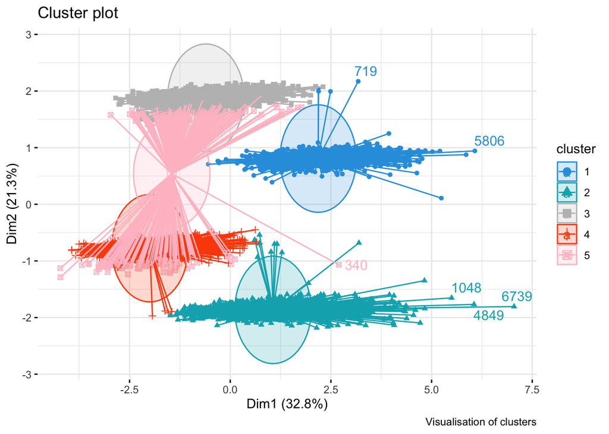

```r
set.seed(123)
km.res <- kmeans(scaled_set, 5, nstart = 25)
kcluster_biom$"cluster"=km.res$cluster
fviz_cluster(km.res,
  data = scaled_set,
  palette = c("#2E9FDF",
              "#00AFBB",
              "grey",
              "#FC4E07",
              "pink"),
  ellipse.type = "euclid",
  star.plot = TRUE,
  repel = TRUE,
  ggtheme = theme_minimal()
)+labs(caption = "Visualisation of clusters")
```

We had standardised our input list and based on this, we visualized the clusters using `fviz_cluster`.

```r
new_group_cluster = tibble(clrt_biom_knn, kcluster_biom$cluster)
colnames(new_group_cluster)[ncol(new_group_cluster)] = "cluster"

new_group_cluster = new_group_cluster%>% select(bmisc, agec, phdkgwbc, sex, exlwvbc, sabdyms, obesity,
                            abspid,
                            sf2sa1qn, ultra_processed,
                            cluster)
kcluster_biom = new_group_cluster
kcluster_biom = kcluster_biom %>% mutate(
  new_ses = case_when(
   sf2sa1qn %in% high_ses ~ "High SES",
   sf2sa1qn %in% low_ses ~ "Low SES"
  )
)
kcluster_biom = kcluster_biom %>% mutate(
  new_obesity = case_when(
   obesity == 1 ~ "OBESE",
   obesity == 0 ~ "NON-OBESE"
  )
)
```

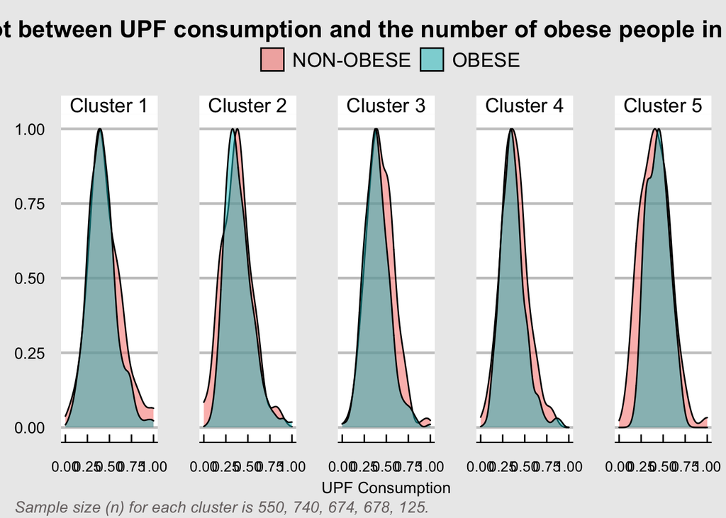

```r
kcluster_biom %>% filter(new_ses == "Low SES") %>%
  ggplot(aes(x = ultra_processed, y=..scaled.., group = new_obesity, fill = new_obesity)) +
  geom_density(alpha = 0.5)+
  facet_grid(. ~ cluster,
              labeller = labeller(cluster = c("1" = "Cluster 1",
                                  "2" = "Cluster 2",
                                 "3" = "Cluster 3",
                                  "4" = "Cluster 4",
                                  "5" = "Cluster 5")))+
  theme_economist_white()+
  theme(panel.spacing = unit(2, "lines"))+
  xlab("UPF Consumption")+
  labs( title = "Density plot between UPF consumption and the number of obese people in low SES group",
    caption = "Sample size (n) for each cluster is 550, 740, 674, 678, 125."
  )+
  theme(axis.title.y=element_blank(),
        axis.title.x = element_text(vjust = -2),
        axis.text.x = element_text(size = 10),
        legend.title=element_blank(),
        plot.title = element_text(hjust = 0.5),
        plot.caption.position = "plot",
        plot.caption = element_text(hjust = 0, face= "italic", vjust = -3.5, colour = "#787272"))+
  theme(panel.spacing = unit(2, "lines"))
```

Since 5 clusters were recommended, we then plot figures to see how the number of obese people would change when UPF consumption varies. Clusters generated before would be introduced as the new variable and figures above were plotted within low SES group.